# A3: SPL Library Checkouts

By Vincent Chen

Date: 2/26/2023

Winter 2023

### Introduction

> An introduction of the data and a description of the trends/books/items you are choosing to analyze (and why!)

In this report, I will be leveraging library checkout data from the Seattle Public Library (SPL). More specifically, the data set encompasses items that have been checked out at least 10 times a month from the year 2017 to 2023. I will be analyzing notions such as the most prevalent type of item checked out within differing years, the year with the most/least number of checkouts, the author with the most checkouts within the data, the month with the most checkouts in 2019, and the most prevalent subject for checkouts in January, 2019.

#### Rationale

I’m interested in exploring how digital and physical item library checkouts fluctuates throughout the years and how events such as the COVID pandemic may influence library checkouts and preferential types of items being checked out more. I’m also interested in exploring the most popular subject in a specified time and which author accounts for the majority of the library checkouts as a means of understanding what types of content and narratives resonates most with SPL attendees.

### The Dataset

> Who collected/published the data?
- The Seattle Public Library

> What are the parameters of the data (dates, number of checkouts, kinds of books, etc.)?
- Data set used: ‘Dataset with items checked out at least 10 times a month from 2017-2023’
- Dates range from 2017 to 2023
- Includes items checked out at least 10 times a month
- 12 columns
- Total of 816,354 checkouts (rows)
- Data was last updated February 6, 2023
- Data set only counts the initial checkout, renewals of physical items are not counted
- Data set includes a monthly count of Seattle Public Library checkouts by title for physical and electronic items

> How was the data collected or generated?
- Digital items in the data set come from the following media vendors: Overdrive, hoopla, Freegal, and RBDigital
- Historical physical item checkouts from April 2005 to September 30, 2016 are sourced from the Legrady artwork data archives
- For October 1, 2016 to present, the source of data derives from the Horizon ILS

> Why was the data collected?
- To improve public understanding of City operations and other information concerning their communities
- Generate economic opportunity for individuals and companies that benefit from the knowledge created by Open Data
- Empower City employees to be more effective, better coordinated internally, and able to identify opportunities to better serve the public
- Encourage the development of innovative technology solutions that improve quality of life
- Increasing transparency, accountability, and comparability; promoting economic development and research; and improving internal performance management

> What, if any, ethical questions do you need to consider when working with this data?
- When working with this data, one must consider the following ethical questions:
  - How might this data impact an authors image?
  - Can this data be used to identify people?
  - Which demographic of people are included and excluded in this data?

> What are possible limitations or problems with this data? (at least 200 words)
- A limitation of this data derives from the fact that it only encompasses checkouts from the Seattle Public Library. By only including a specific library branch in the data set, it excludes data from other libraries in Washington state and worldwide. Essentially, this narrows down the scope and generalization capabilities of exploring trends and patterns in library checkouts across the general public.
- Another limitation of this data is the library checkouts only include the monthly count and specified year-for-date context. Although sufficient for exploring general trends and patterns across different months within a year, the absence of the full date prevents further analysis in analyzing patterns throughout the days of the week. It would be interesting to be able to compare the frequency of library checkouts towards the beginning of the month to the end of the month and compare prevalence during the weekdays versus the weekend.
- A problem with this data set is the inconsistency in format with the ‘PublicationYear’ field. By having many formatting varieties, it becomes difficult to work with this field in data analysis and garner accurate insights.
- Another problem with this data set derives from instances of blank subject headings and other fields for older checkouts in the data. This absence of information makes it difficult to fully analyze trends and patterns in the past.

### First Trends Over Time Chart

> Include a chart. Make sure to describe why you included the chart, and what patterns emerged

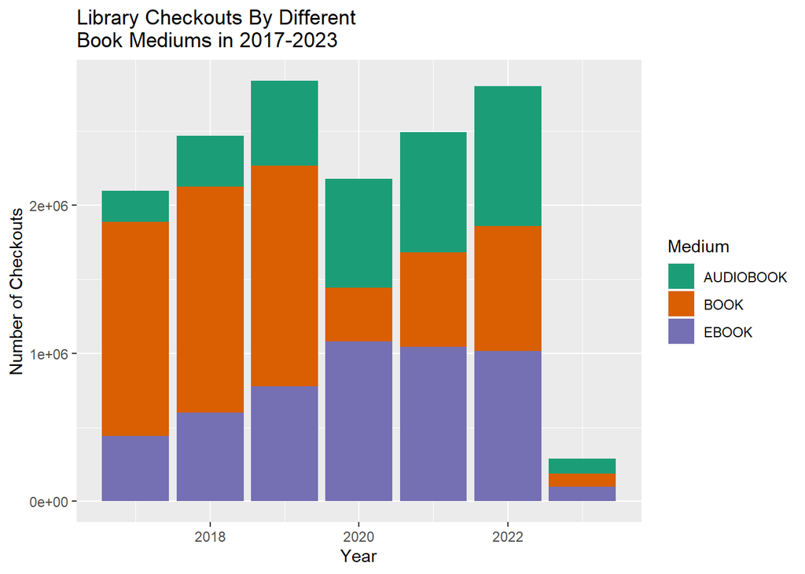

This chart displays the prevalence of 3 different book mediums for library checkouts between 2017 and 2023.

#### Rationale

By filtering library checkouts by differing book mediums and grouping the records by checkout year, it allows us to visually analyze the patterns and fluctuations in physical and digital book consumption throughout the years.

### Second Trends Over Time Chart

> Include a chart. Make sure to describe why you included the chart, and what patterns emerged

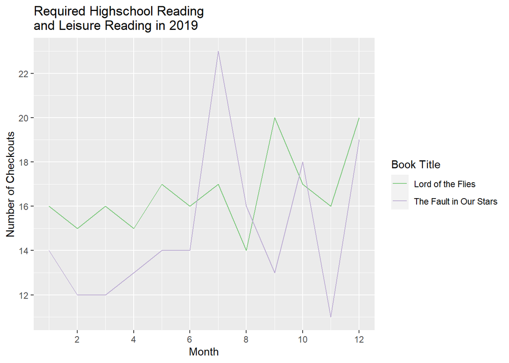

This chart displays the monthly fluctuations in library checkouts between two books in 2019.

#### Rationale

With this chart, I wanted to compare a required high school reading (‘Lord of the Flies’) and a popular fun reading (‘The Fault in Our Stars’) among people that are presumably in the same age bracket. I chose the year 2019 due to the higher volume of library checkouts in comparison to other years, and being prior to the onslaught of the COVID pandemic. My motivation derives from wanting to explore if there’s patterns in library checkouts throughout the months, with emphasis on looking at ‘summer vacation’ months and ‘school year’ months objectively.

### Your Choice

> The last chart is up to you. It could be a line plot, scatter plot, histogram, bar plot, stacked bar plot, and more. Here are some requirements to help guide your design:

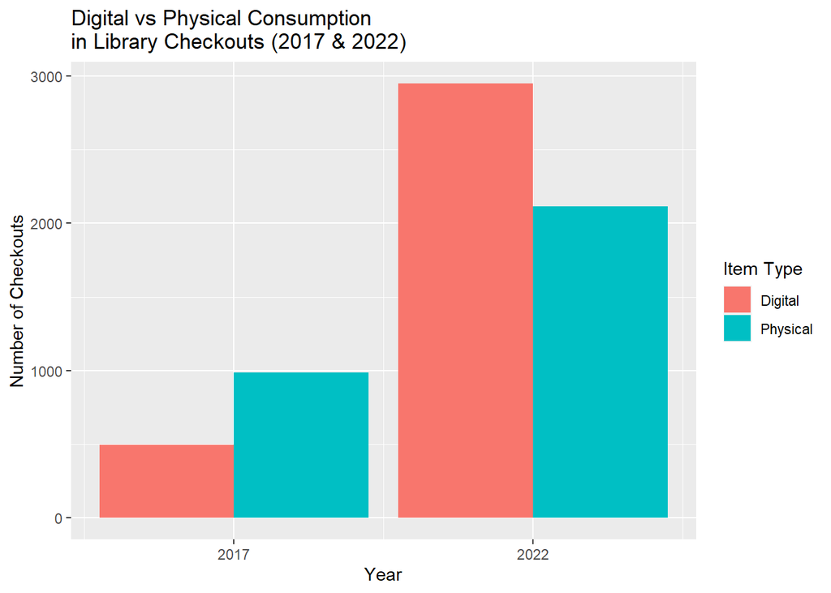

This chart displays the prevalence of digital versus physical item checkouts in the year 2017 and 2022.

#### Rationale

- With this chart, I wanted to explore the general trends and patterns in digital and physical item checkouts. I chose to use the year 2017 as it’s the earliest year in the data set and decided to use the year 2022 as it’s the most recent year in the data set that fully accounts for library checkouts. The year 2023 is still in-progress and incomplete, so I decided to not use that year for comparative analysis. I hope to explore how the prevalence of digital and physical item checkouts change between an earlier year and more present year in the data.

#### Insights

- In 2017, physical item checkouts make up the majority of library checkouts
- In 2017, physical item checkouts account for about 1000 checkouts, which is about twice as many as digital item checkouts
- In 2022, digital item checkouts account for a larger portion of the library checkouts, at roughly 2900 checkouts